# Legends

Author

Daven

## 1 Basic Box Plot

- `library(ggplot2)`: This loads the `ggplot2` library.
- `ggplot(PlantGrowth, aes(x = group, y = weight))`:
  - Uses the built-in `PlantGrowth` dataset
  - Creates a plot with `group` on the x-axis and `weight` on the y-axis
  - `aes()` defines the aesthetic mappings of the plot
- `geom_boxplot()`: Adds a box plot geometry to visualize the distribution of weights across different groups
- `labs(title = 'Basic Box Plot', caption = 'By Daven, DV, THU, 2024')`: Adds a title and caption to the plot
- `theme(plot.title = element_text(hjust = 0.5, size = 20))`: Centers the title horizontally `(hjust = 0.5)` and size of the text to `size = 20`

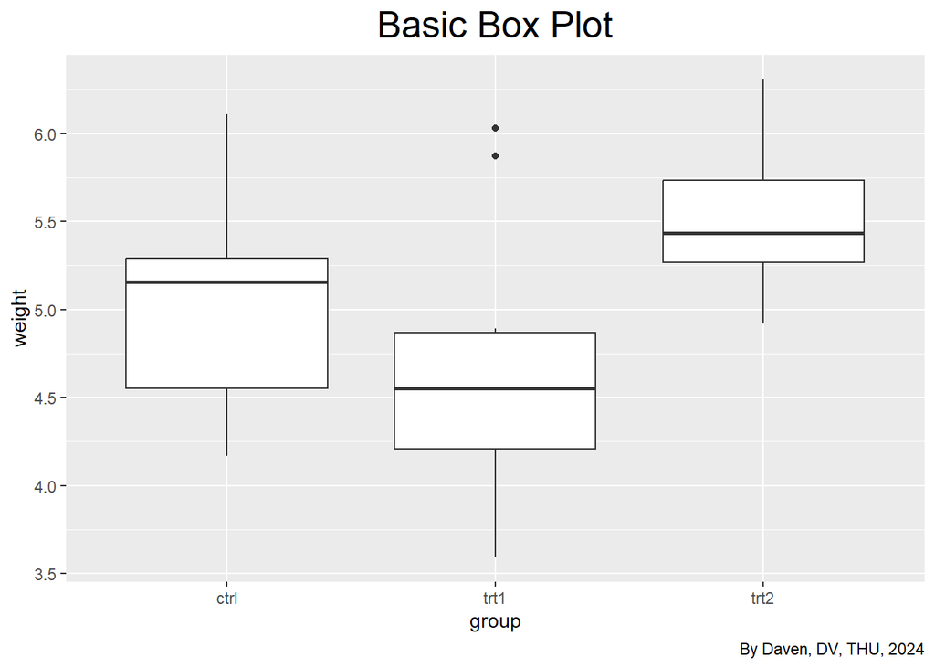

```r
library(ggplot2)

ggplot(PlantGrowth, aes (x = group, y = weight)) +
  geom_boxplot() +
  labs(title = 'Basic Box Plot',
       caption = 'By Daven, DV, THU, 2024') +
  theme(plot.title = element_text(hjust = 0.5, size = 20))
```

## 2 Add a Legend

- `library(gridExtra)`: this load the `gridExtra` library
- `fill`: to add color inside the area of the box
- `color`: to add color around the outline of the box
- `grid.arrange()`: used to arrange multiple grid-based plots on a single page
- `ncol`: used to determine the number of column within the box plot chart
- `top`: Adds title into the box plot chart
- `bottom`: Adds caption into the box plot chart

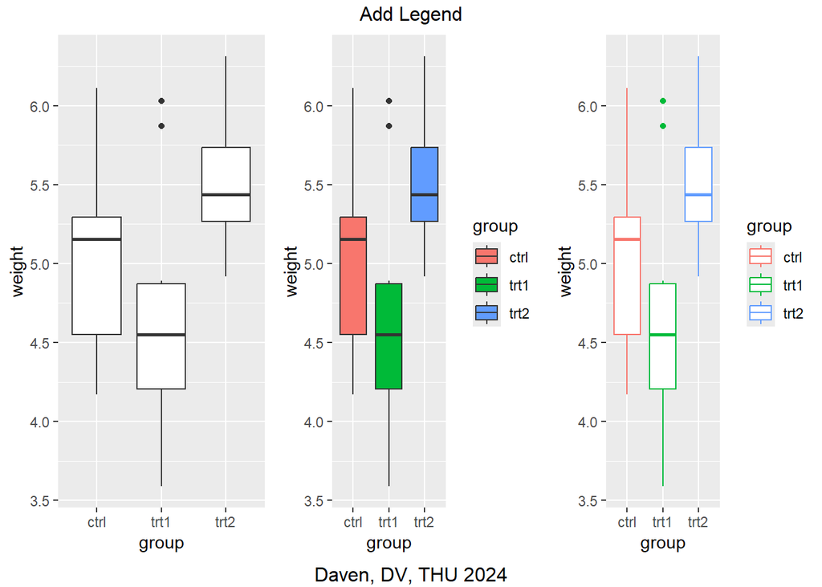

```r
library(ggplot2)
library(gridExtra)

p1 <- ggplot(PlantGrowth, aes(x = group, y = weight)) +
  geom_boxplot()

p2 <- ggplot(PlantGrowth, aes(x = group, y = weight, fill = group)) +
  geom_boxplot()

p3 <- ggplot(PlantGrowth, aes(x = group, y = weight, color = group)) +
  geom_boxplot()

grid.arrange(p1, p2, p3, ncol = 3, top = 'Add Legend',
             bottom = 'Daven, DV, THU 2024')
```

## 3 Remove Legend

Using the same chart in Basic Box Plot, The legend is removed by `guides(fill = FALSE)`

- `guides(fill)`: use to activating/disabling legends

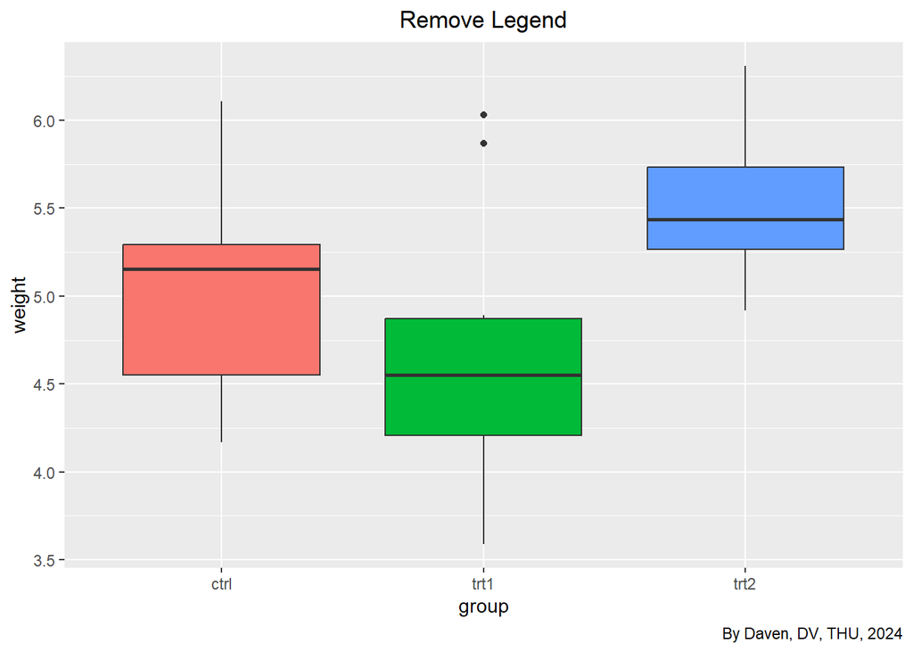

```r
ggplot(PlantGrowth, aes(x = group, y = weight, fill = group)) +
  geom_boxplot() +
  guides(fill = FALSE) +
  labs(title = 'Remove Legend',
       caption = 'By Daven, DV, THU, 2024') +
  theme(plot.title = element_text(hjust=0.5))
```

## 4 Change Color of Legend

Using the same chart in Basic Box Plot, we’ll change the box plot’s `fill` using `"Pastel2"`

- `scale_fill_brewer(palette = "Pastel2")`:
  - `scale_fill_brewer()`: add aesthetically pleasing color palettes to the box plot
  - `palette = "Pastel2"`: give `"Pastel2"` color palette to the box plot

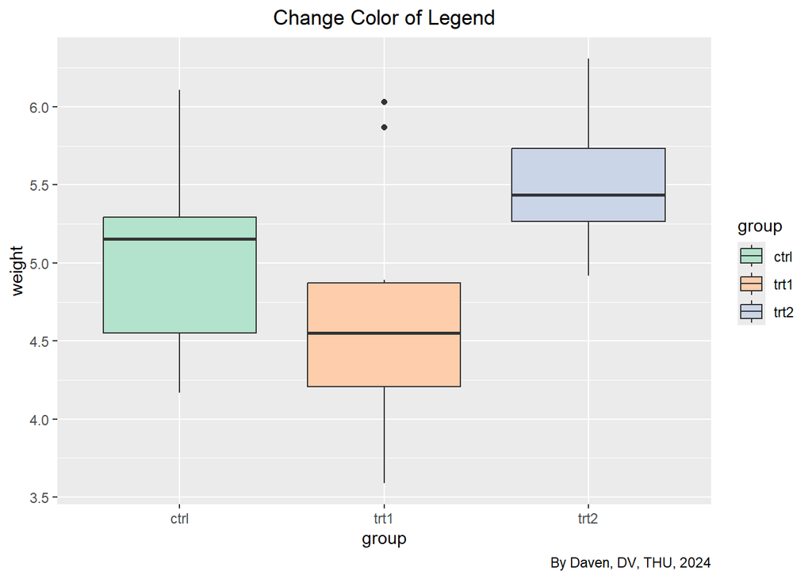

```r
ggplot(PlantGrowth, aes(x = group, y = weight, fill = group)) +
  geom_boxplot() +
  scale_fill_brewer(palette = "Pastel2") +
  labs(title = 'Change Color of Legend',
       caption = 'By Daven, DV, THU, 2024') +
  theme(plot.title = element_text(hjust=0.5))
```

## 5 Change Posistion of Legend

Continuing from Change Color of Legend, we’ll change the legend’s position to the `top`

- `theme(plot.title = element_text(hjust = 0.5), legend.position = 'top')`:
  - Centers the title horizontally `(hjust=0.5)`
  - Putting the legend’s position on top of the box plot chart `legend.position = 'top'`

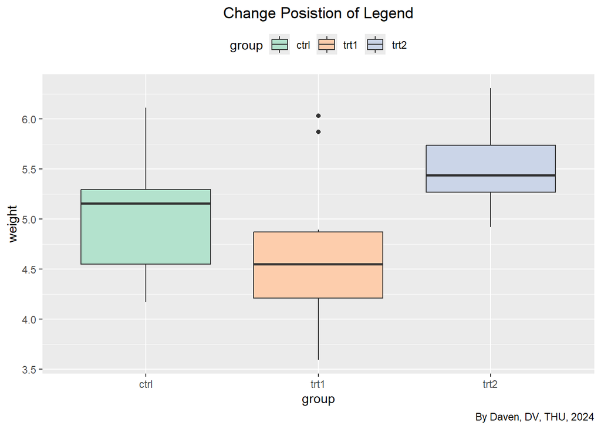

```r
ggplot(PlantGrowth, aes(x = group, y = weight, fill = group)) +
  geom_boxplot() +
  scale_fill_brewer(palette = "Pastel2") +
  labs(title = 'Change Posistion of Legend',
       caption = 'By Daven, DV, THU, 2024') +
  theme(plot.title = element_text(hjust=0.5),
        legend.position = 'top')
```

## 6 Practice

Change `legend` position to `top`, `bottom`, `left`, and `right`.

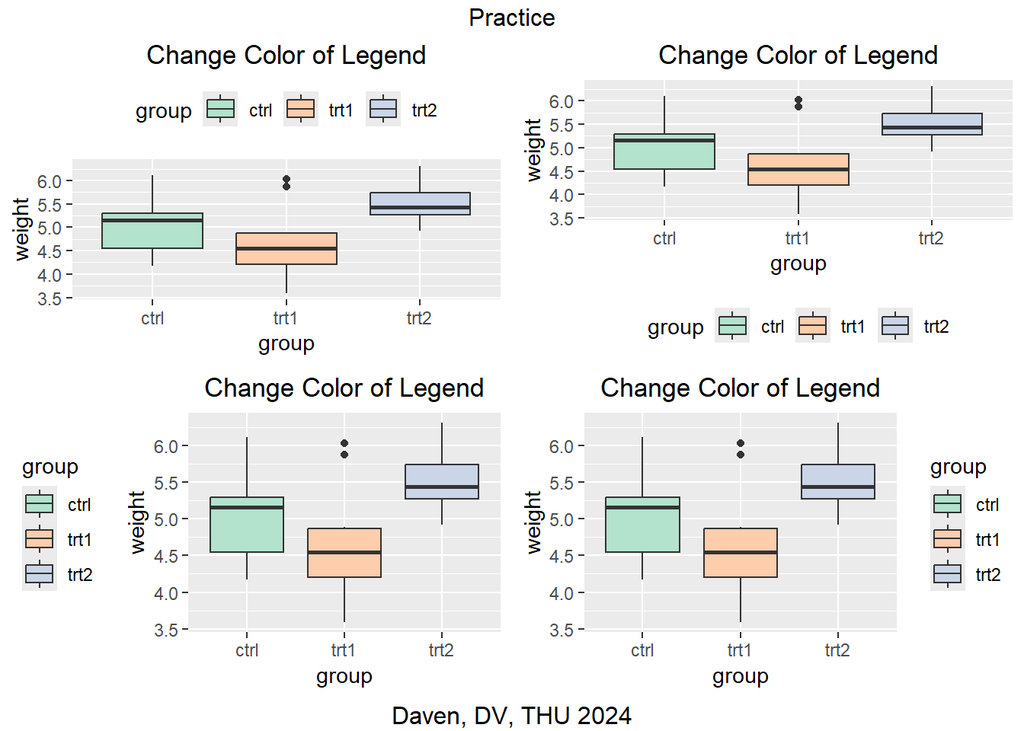

```r
p1 <- ggplot(PlantGrowth, aes(x = group, y = weight, fill = group)) +
  geom_boxplot() +
  scale_fill_brewer(palette = "Pastel2") +
  ggtitle('Change Color of Legend') +
  theme(plot.title = element_text(hjust = 0.5),
        legend.position = 'top')
p2 <- p1 + theme(legend.position = 'bottom')
p3 <- p1 + theme(legend.position = 'left')
p4 <- p1 + theme(legend.position = 'right')

grid.arrange(p1, p2, p3, p4, ncol=2,
             top = 'Practice',
             bottom = 'Daven, DV, THU 2024')
```

## 7 Change Coordinate of Legend

Using the same chart in Change Color of Legend, we’ll change the `coordinate` of the legend

- `legend.position = c(x, y)`:
  - Setting the coordinates of the legend’s position as a proportion of the chart
    - `x`: horizontal position
    - `y`: vertical position
- `legend.justification = c()`:
  - Controls the anchor point of the legend that aligns with the specified position
    - `x`: horizontal justification
    - `y`: vertical justification

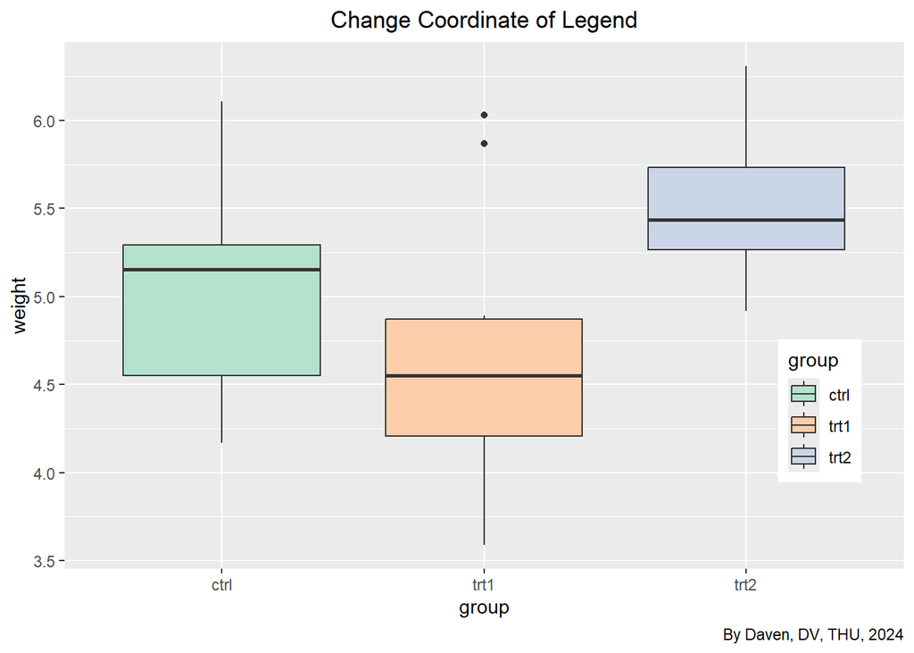

```r
ggplot(PlantGrowth, aes(x = group, y = weight, fill = group)) +
  geom_boxplot() +
  scale_fill_brewer(palette = "Pastel2") +
  labs(title = 'Change Coordinate of Legend',
       caption = 'By Daven, DV, THU, 2024') +
  theme(plot.title = element_text(hjust = 0.5),
        legend.position = c(.9, .3))
```

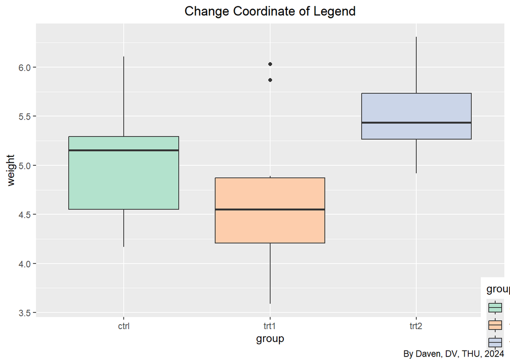

```r
ggplot(PlantGrowth, aes(x = group, y = weight, fill = group)) +
  geom_boxplot() +
  scale_fill_brewer(palette = "Pastel2") +
  labs(title = 'Change Coordinate of Legend',
       caption = 'By Daven, DV, THU, 2024') +
  theme(plot.title = element_text(hjust = 0.5),
        legend.position = c(1, 0))
```

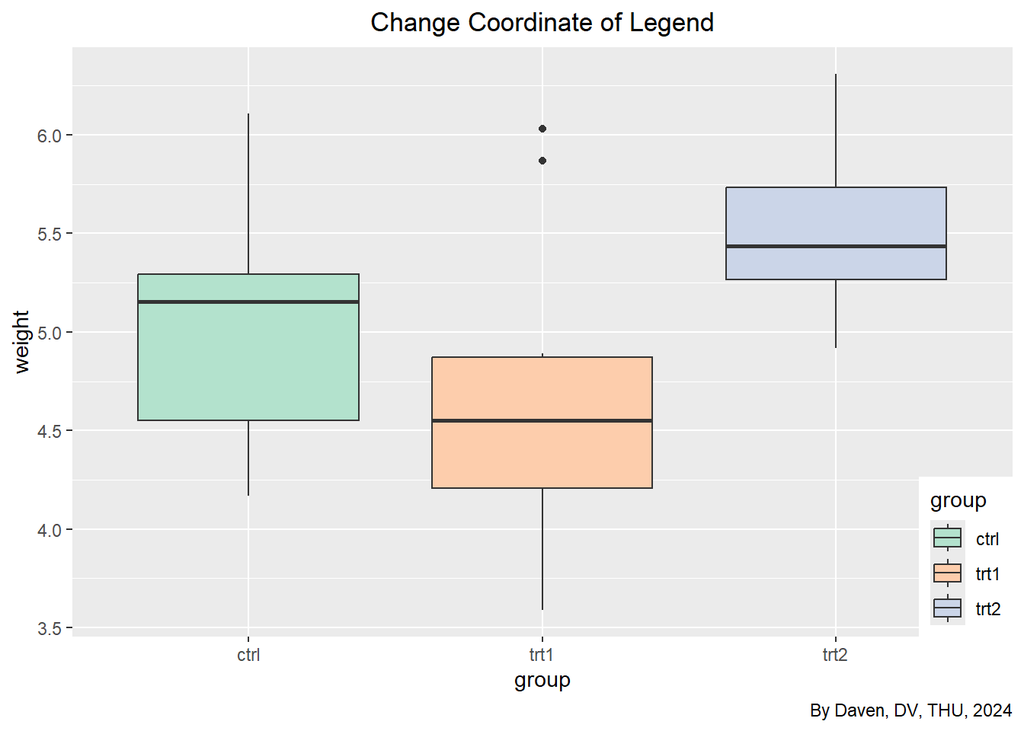

```r
ggplot(PlantGrowth, aes(x = group, y = weight, fill = group)) +
  geom_boxplot() +
  scale_fill_brewer(palette = "Pastel2") +
  labs(title = 'Change Coordinate of Legend',
       caption = 'By Daven, DV, THU, 2024') +
  theme(plot.title = element_text(hjust = 0.5),
        legend.position = c(1, 0),
        legend.justification = c(1, 0))
```

## 8 Change Border of Legend

Using the same chart in Change Color of Legend, we’ll change the `border` of the legend

`legend.background = element_rect(fill = 'white', color = 'black'))`:

- `legend.background`: applies an `element_rect()` to the legend’s background.
- `element_rect()`: provides the customization options for the legends’ style

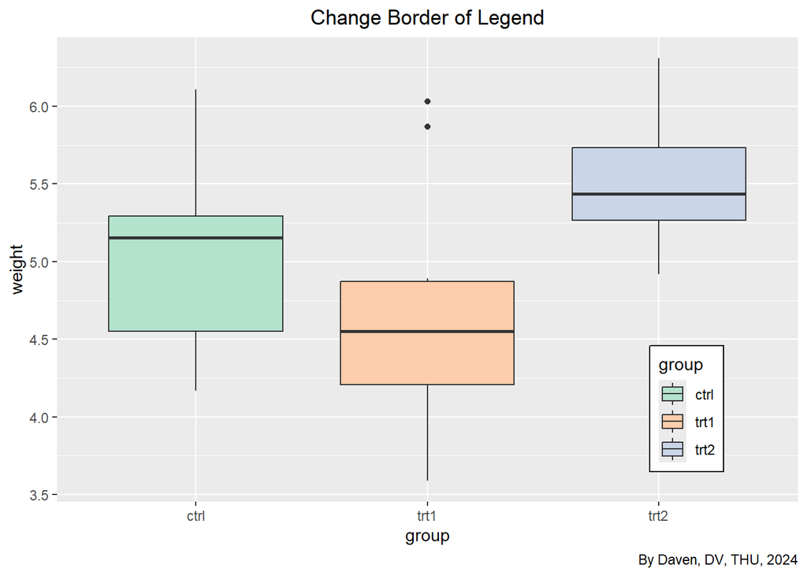

```r
ggplot(PlantGrowth, aes(x = group, y = weight, fill = group)) +
  geom_boxplot() +
  scale_fill_brewer(palette = "Pastel2") +
  labs(title = 'Change Border of Legend',
       caption = 'By Daven, DV, THU, 2024') +
  theme(plot.title = element_text(hjust = 0.5),
        legend.position = c(0.85, 0.2),
        legend.background = element_rect(fill = 'white',
                                         color = 'black'))
```

## 9 Change background of Legend

Using the same chart in Change Color of Legend, we’ll change the `background` of the legend

- `legend.key`: appearance of the box inside the legend
- `element_blank()`: removes an element from the legend

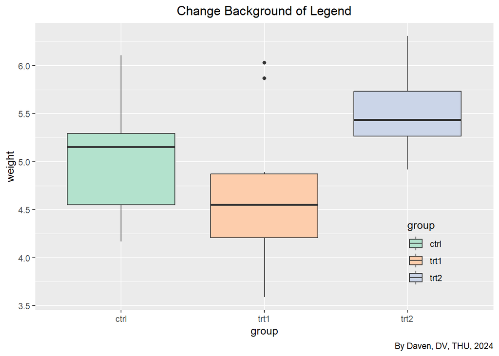

```r
ggplot(PlantGrowth, aes(x = group, y = weight, fill = group)) +
  geom_boxplot() +
  scale_fill_brewer(palette = "Pastel2") +
  labs(title = 'Change Background of Legend',
       caption = 'By Daven, DV, THU, 2024') +
  theme(plot.title = element_text(hjust = 0.5),
        legend.position = c(0.85, 0.2),
        legend.background = element_blank(),
        legend.key = element_blank())
```

## 10 Change Order of Items in Legend

Using the same chart in Change Color of Legend, we’ll change the `items order` of the legend

- `scale_fill_discrete()`: Controls the aesthetic mapping of discrete values
- `limits`: Specifies the order and inclusion of levels for the discrete scale

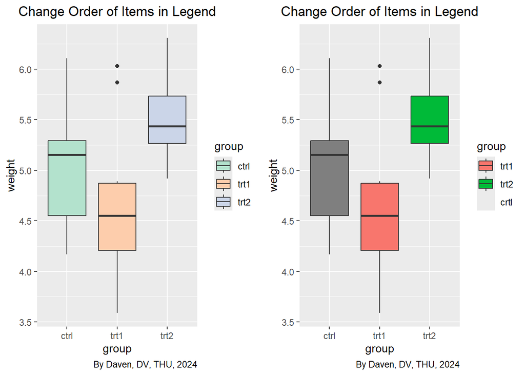

```r
p1 <- ggplot(PlantGrowth, aes(x = group, y = weight, fill = group)) +
  geom_boxplot() +
  scale_fill_brewer(palette = "Pastel2") +
  labs(title = 'Change Order of Items in Legend',
       caption = 'By Daven, DV, THU, 2024') +
  theme(plot.title = element_text(hjust = 0.5))

p2 <- p1 + scale_fill_discrete(limits = c('trt1', 'trt2', 'crtl'))

grid.arrange(p1, p2, ncol = 2)
```

## 11 Reverse Order of Items in Legend

Using the same chart in Change Color of Legend, we’ll reverse the `item order` in the legend

- `guide()`: used to customize legends and axes guides
- `fill = guide_legend()`: specify the guide for discrete legends

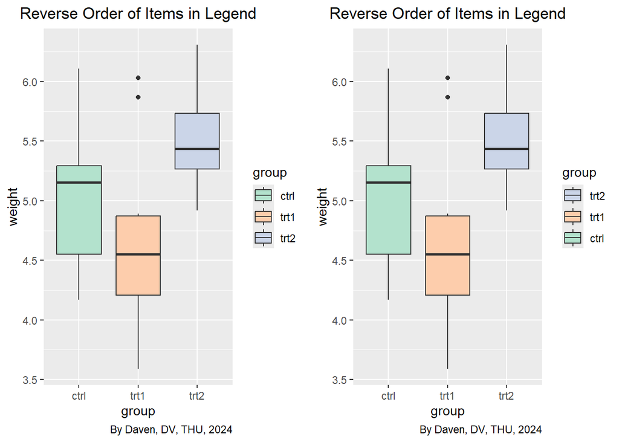

```r
p1 <- ggplot(PlantGrowth, aes(x = group, y = weight, fill = group)) +
  geom_boxplot() +
  scale_fill_brewer(palette = "Pastel2") +
  labs(title = 'Reverse Order of Items in Legend',
       caption = 'By Daven, DV, THU, 2024') +
  theme(plot.title = element_text(hjust = 0.5))

p2 <- p1 + guides(fill = guide_legend(reverse = TRUE))

grid.arrange(p1, p2, ncol = 2)
```

## 12 Change Legend Title

Using the same chart in Change Color of Legend, we’ll change the legend `title`

- `labs(fill = 'Condition')`: add `'Condition'` title as a legend title

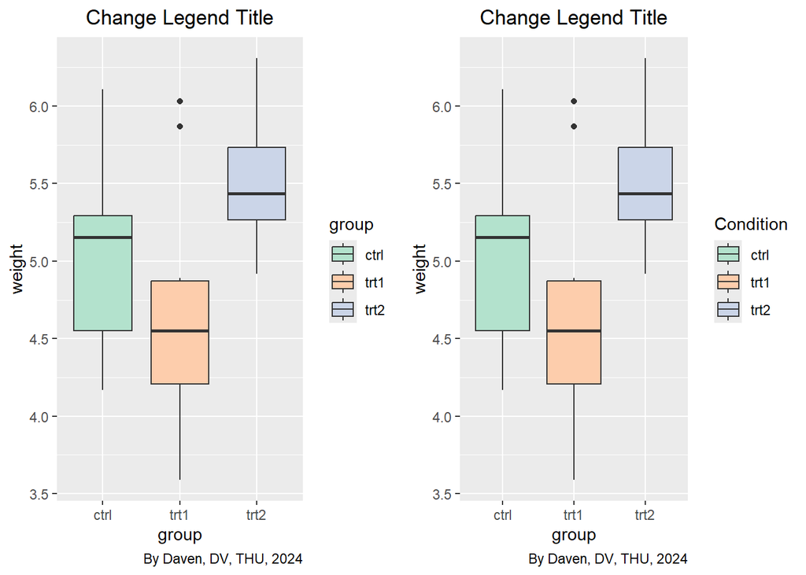

```r
p1 <- ggplot(PlantGrowth, aes(x = group, y = weight, fill = group)) +
  geom_boxplot() +
  scale_fill_brewer(palette = "Pastel2") +
  labs(title = 'Change Legend Title',
       caption = 'By Daven, DV, THU, 2024') +
  theme(plot.title = element_text(hjust = 0.5))

p2 <- p1 + labs(fill = 'Condition')

grid.arrange(p1, p2, ncol = 2)
```